# R 패키지 ggplot2을 이용한 자료의 시각화

## 2.2 산포도

```r
library(MVA)
head(USairpollution)
```

```
##             SO2 temp manu popul wind precip predays
## Albany       46 47.6   44   116  8.8  33.36     135
## Albuquerque  11 56.8   46   244  8.9   7.77      58
## Atlanta      24 61.5  368   497  9.1  48.34     115
## Baltimore    47 55.0  625   905  9.6  41.31     111
## Buffalo      11 47.1  391   463 12.4  36.11     166
## Charleston   31 55.2   35    71  6.5  40.75     148
```

다음 명령어가 기본적인 산점도를 그리는 명령어이다.

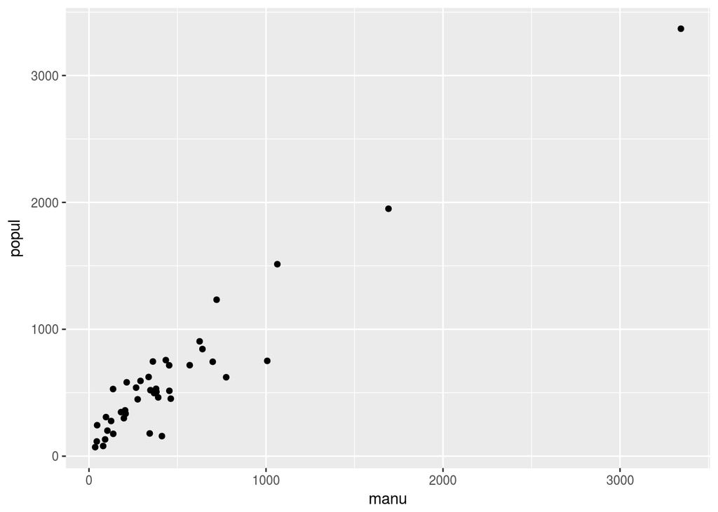

```r
g<- ggplot(USairpollution, aes(x=manu, y=popul)) + geom_point()
g
```

다음은 산점도에 여러 가지 특징(제목, 축의 이름, 축의 구간 설정, 회귀직선의 추가)를 추가하는 명령어이다.

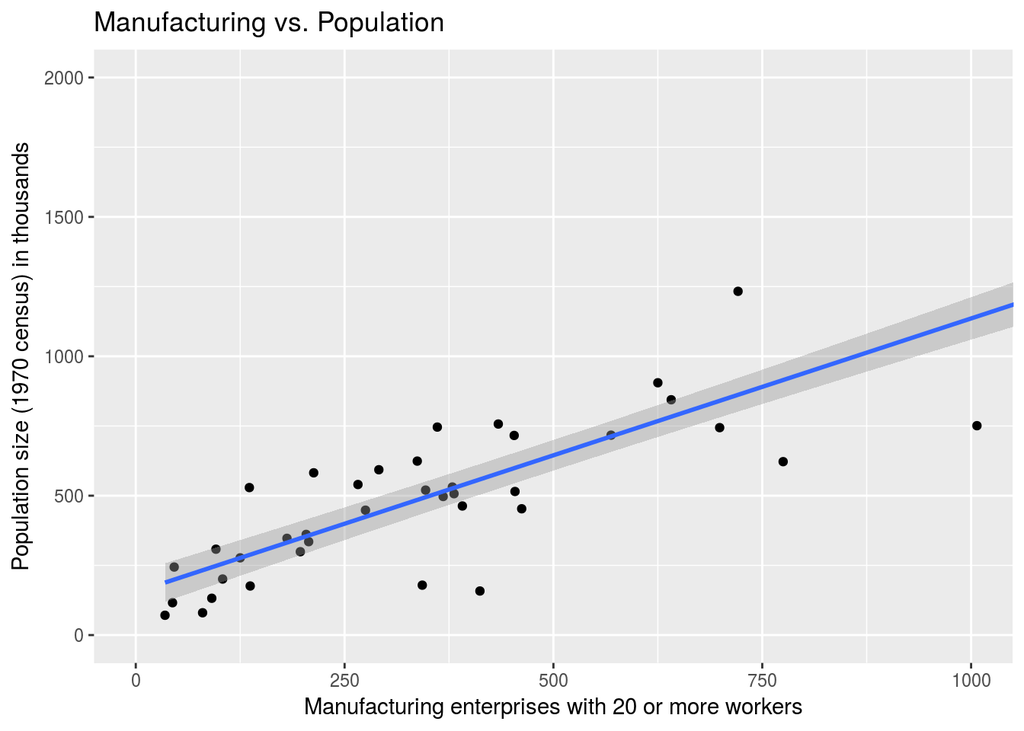

```r
xxlab <- "Manufacturing enterprises with 20 or more workers"
yylab <- "Population size (1970 census) in thousands"
g <- g +  ggtitle("Manufacturing vs. Population") + xlab(xxlab) + ylab(yylab)
g <- g +  coord_cartesian(xlim=c(0,1000), ylim=c(0, 2000))
g <- g +  geom_smooth(method="lm")
g
```

다음은 산점도에서 주어진 그룹뱔로 점의 색깔이나 형태를 다르게 나타내는 명령어이다.

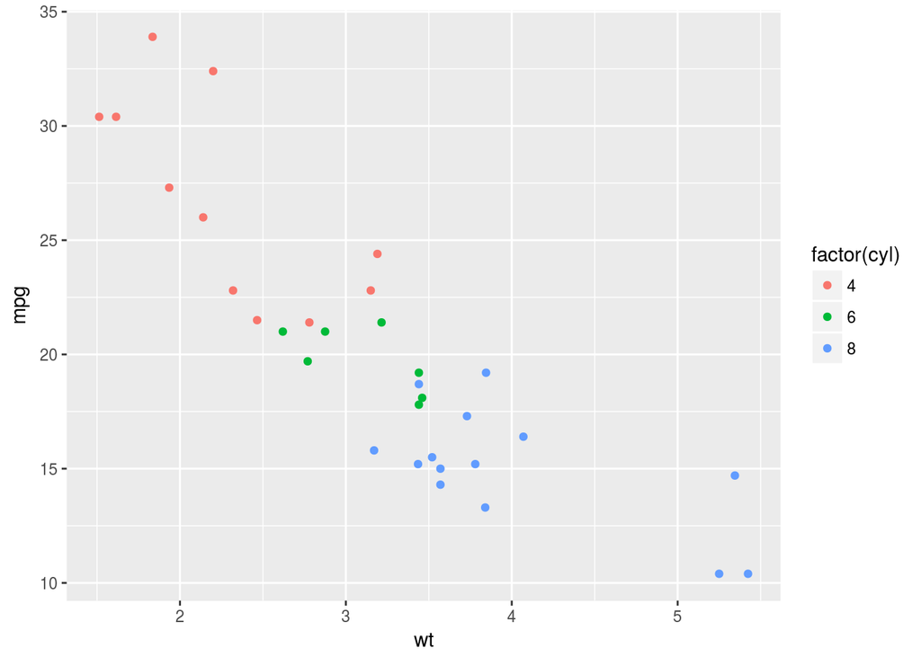

```r
 p <- ggplot(mtcars, aes(wt, mpg))
 p + geom_point(aes(colour = factor(cyl)))
```

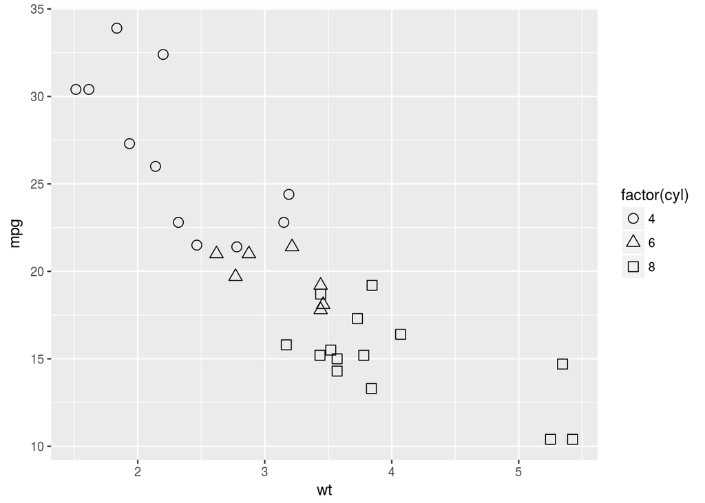

```r
 p + geom_point(aes(shape = factor(cyl)), size = 3) + scale_shape(solid = FALSE)
```

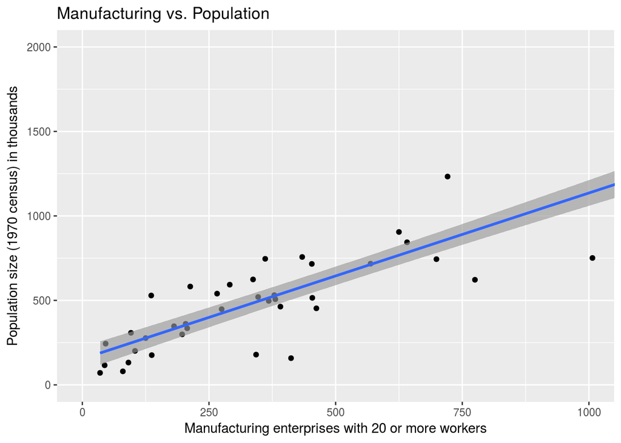

```r
xxlab <- "Manufacturing enterprises with 20 or more workers"
yylab <- "Population size (1970 census) in thousands"
g <- g +  ggtitle("Manufacturing vs. Population") + xlab(xxlab) + ylab(yylab)
g <- g +  coord_cartesian(xlim=c(0,1000), ylim=c(0, 2000))
g <- g +  geom_smooth(method="lm")
g
```

```r
library("GGally")
```

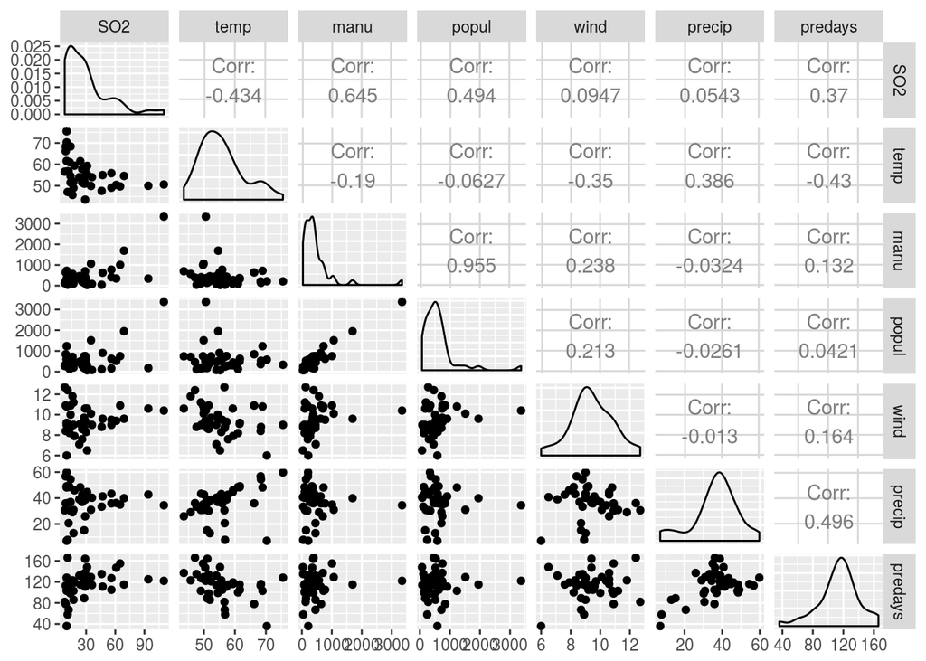

```r
ggpairs(USairpollution)
```

# 3 반복측정자료의 시각화

반복측정자료는 하나의 개체에서 2개 이상의 여러 개 자료를 측정한 자료이다. 이러한 자료는 각 개체별로 산점도를 그리는 것이 분석에 큰 도움이 된다.

**lme4** 패키지에 자료인 `spleepstudy`는 화물트럭 운전사들에 대한 수면부족 현상에 대하여 연구한 자료이다. 18명의 운전자들이 매일 3시간의 수면(부족한 수면)을 하면서 매일 일정한 동작의 반응시간을 10일동안 반복적으로 측정한 자료가 있다. 한명의 운전사에게 10일 동안의 반응에 대한 측정자료 10개가 존재하므로 이는 반복측정 자료이며 이러한 10개의 자료는 독립이 아니다.

```r
library(lme4)
str(sleepstudy)
```

```
## 'data.frame':    180 obs. of  3 variables:
##  $ Reaction: num  250 259 251 321 357 ...
##  $ Days    : num  0 1 2 3 4 5 6 7 8 9 ...
##  $ Subject : Factor w/ 18 levels "308","309","310",..: 1 1 1 1 1 1 1 1 1 1 ...
```

```r
head(sleepstudy,n=20)
```

```
##    Reaction Days Subject
## 1  249.5600    0     308
## 2  258.7047    1     308
## 3  250.8006    2     308
## 4  321.4398    3     308
## 5  356.8519    4     308
## 6  414.6901    5     308
## 7  382.2038    6     308
## 8  290.1486    7     308
## 9  430.5853    8     308
## 10 466.3535    9     308
## 11 222.7339    0     309
## 12 205.2658    1     309
## 13 202.9778    2     309
## 14 204.7070    3     309
## 15 207.7161    4     309
## 16 215.9618    5     309
## 17 213.6303    6     309
## 18 217.7272    7     309
## 19 224.2957    8     309
## 20 237.3142    9     309
```

각 운전자에 대하여 다음과 같은 단순선형회귀직선을 적합하여 각 산점도에 회귀직선을 포함시키고자 한다.

$$y_{ij} = \beta_{0i} + \beta_{1i} t_j + e_{ij}$$

개체(운전사)에 대하여 각각 회귀직선을 적합시켜서 절편과 기울기를 구하는 명령은 `lmlist()` 함수를 사용한다.

```r
coef_res <- lmList(Reaction ~ Days | Subject, sleepstudy)
coef_res
```

```
## Call: lmList(formula = Reaction ~ Days | Subject, data = sleepstudy)
## Coefficients:
##     (Intercept)      Days
## 308    244.1927 21.764702
## 309    205.0549  2.261785
## 310    203.4842  6.114899
## 330    289.6851  3.008073
## 331    285.7390  5.266019
## 332    264.2516  9.566768
## 333    275.0191  9.142045
## 334    240.1629 12.253141
## 335    263.0347 -2.881034
## 337    290.1041 19.025974
## 349    215.1118 13.493933
## 350    225.8346 19.504017
## 351    261.1470  6.433498
## 352    276.3721 13.566549
## 369    254.9681 11.348109
## 370    210.4491 18.056151
## 371    253.6360  9.188445
## 372    267.0448 11.298073
##
## Degrees of freedom: 180 total; 144 residual
## Residual standard error: 25.59182
```

다음과 같은 `ggplot2`의 명령어로 산점도와 각 개체에 대한 회귀직선을 하나의 그림에 그릴 수 있다.

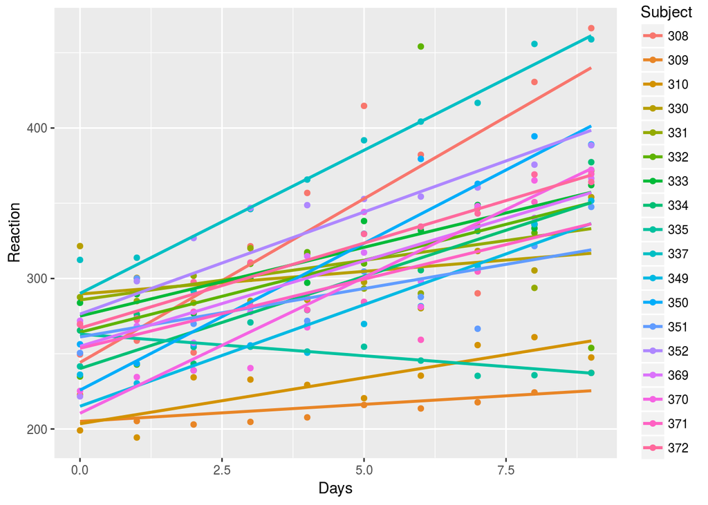

```r
ggplot(sleepstudy, aes(x=Days, y=Reaction,colour=Subject)) +
  geom_point() +
  geom_smooth(se = FALSE, method = "lm")
```

다음과 같은 `ggplot2`의 명령어로 각 개체에 대한 산점도 행렬를 그릴 수 있다.

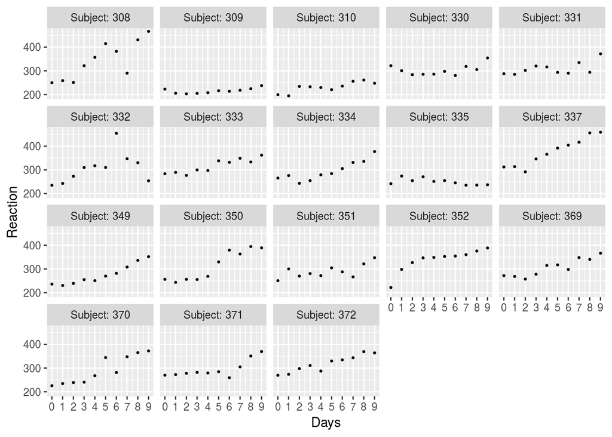

```r
ggplot(sleepstudy, aes(x=Days, y=Reaction)) +
    geom_point(size=0.5) +
    scale_x_continuous(breaks=0:9) +
    facet_wrap("Subject", labeller = label_both)
```

다음과 같은 `ggplot2`의 명령어로 각 개체에 대한 산점도 행렬과 회귀직선을 그릴 수 있다. `facet_wrap("Subject")`은 그림을 각 개체별로 따로 그리는 구성요소이며 `stat_smooth(method = "lm")`는 회귀직선을 추가하는 구성요소이다.

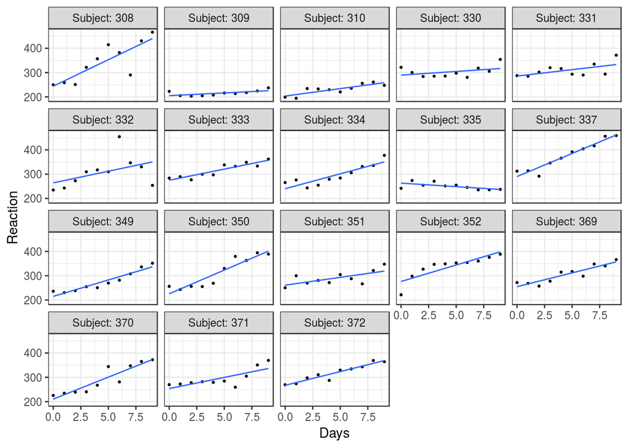

```r
ggplot(sleepstudy, aes(x=Days, y=Reaction)) +
     geom_point(size=0.5) +
     stat_smooth(method = "lm",se=F,size=0.5)+
     facet_wrap("Subject", labeller = label_both)+
     theme_bw()
```

그림을 그릴수 있는 패키지인 `lattice`를 이용하면 각 운전자에 대한 10일 간의 반응속도가 날짜에 대하여 어떻게 변하는 가를 알아보자. `lattice` 패키지는 복잡한 그림을 그리는데 있어서 `ggplot2`보다 그 문법이 더 복잡하여 사용하기 쉽지 않다.

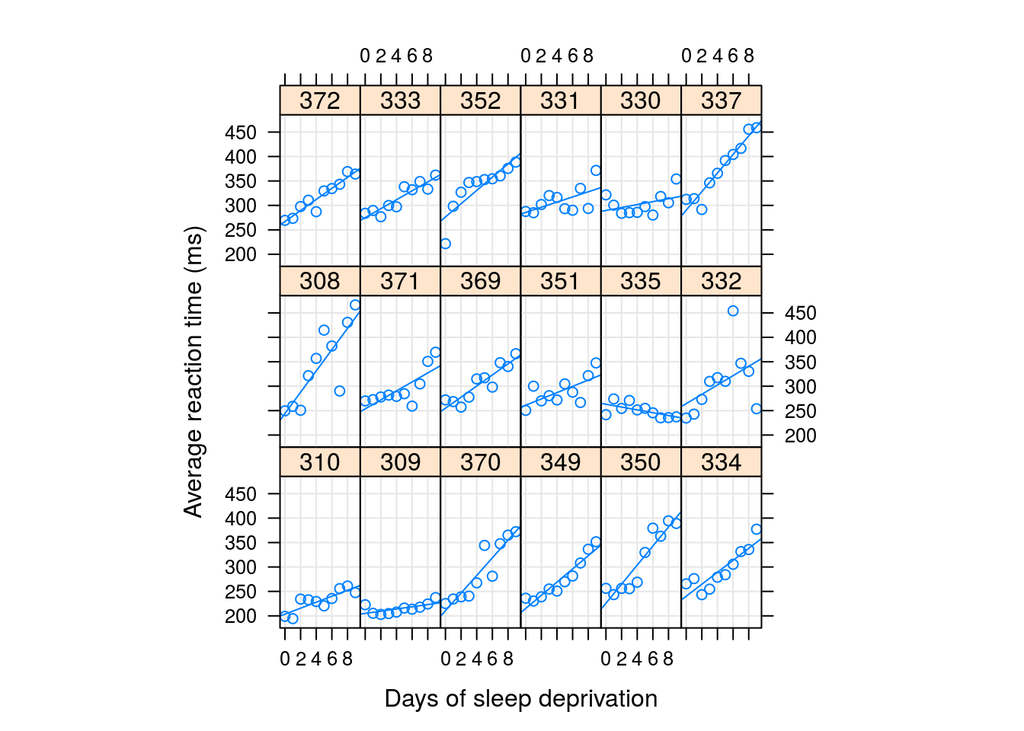

```r
library(lattice)
print(xyplot(Reaction ~ Days | Subject, sleepstudy, aspect = "xy",
             layout = c(6,3), type = c("g", "p", "r"),
             index.cond = function(x,y) coef(lm(y ~ x))[1],
             xlab = "Days of sleep deprivation",
             ylab = "Average reaction time (ms)"))
```